# Regression Analysis on MNIST Dataset

```r
library(ggplot2)
```

## Objective

Objective of this project is to implement logistic regression for classification of digits on MNIST image dataset and evaluate how the behavior of the model is affected when parameters and sizes of the training set is changed.

## MNIST Dataset

The MNIST database (Modified National Institute of Standards and Technology database) is a large database of handwritten digits that is commonly used for training various image processing systems. Original MNIST database contains 60,000 training images and 10,000 testing images.

For this project I have chosen a subset of the original MNIST dataset, where the images of only four digits have been included (0, 1, 3 and 5). As a further simplification, I will only attempt binary classification in this project.

Dataset contains two CSV files viz. mnist_test.csv and mnist_train.csv. Each CSV file contains <785 rows x n columns>, where n is the number of sample images in the file. Each column represents one 28×28 image of a digit stacked into a 784 length vector followed by the class label (0, 1, 3 or 5).

## Implementation Steps

Implementation of this project is carried out in following steps: 1. Data Preprocessing 2. Building Model 3. Predicting Labels 4. Calculating Accuracy 5. Visualizing Results

## 1. Data Preprocessing

In this step training and testing data is read and loaded into separate matrices. In order to seperate feature columns from label column both of the matrices are transposed. Training and Test dataset is then sudivided into two data sets. One dataset consists of labels 0 or 1 while other consists of labels 3 or 5. In both dataset label column is updated to either 1 or -1 with fllowing logic: 0 changed to -1, 1 remained as 1, 3 changed to -1 and 5 changed to 1. A new labels vector is created and feature matrix is updated to include additional bias term (set to 1). Bias term allows the model to have more flexibility.

```r
traindf <-t(read.csv(file='mnist_train.csv', header=FALSE))
testdf <- t(read.csv(file='mnist_test.csv', header=FALSE))

train_0_1 <- subset(traindf, traindf[,ncol(traindf)]==0 | traindf[,ncol(traindf)]==1)
train_3_5 <- subset(traindf, traindf[,ncol(traindf)]==3 | traindf[,ncol(traindf)]==5)
test_0_1 <- subset(testdf, testdf[,ncol(testdf)]==0 | testdf[,ncol(testdf)]==1)
test_3_5 <- subset(testdf, testdf[,ncol(testdf)]==3 | testdf[,ncol(testdf)]==5)

train_labels_0_1 <- as.vector(train_0_1[,ncol(train_0_1)])
train_labels_0_1[train_labels_0_1 == 0 ] <- -1

test_labels_0_1 <- as.vector(test_0_1[,ncol(test_0_1)])
test_labels_0_1[test_labels_0_1 == 0 ] <- -1

train_labels_3_5 <- as.vector(train_3_5[,ncol(train_3_5)])
train_labels_3_5[train_labels_3_5 == 3 ] <- -1
train_labels_3_5[train_labels_3_5 == 5 ] <- 1

test_labels_3_5 <- as.vector(test_3_5[,ncol(test_3_5)])
test_labels_3_5[test_labels_3_5 == 3 ] <- -1
test_labels_3_5[test_labels_3_5 == 5 ] <- 1

train_0_1 <- train_0_1[,-ncol(train_0_1)]
test_0_1 <- test_0_1[,-ncol(test_0_1)]
train_3_5 <- train_3_5[,-ncol(train_3_5)]
test_3_5 <- test_3_5[,-ncol(test_3_5)]

train_0_1 <- cbind(train_0_1, rep_len(1, nrow(train_0_1)))
test_0_1 <- cbind(test_0_1, rep_len(1, nrow(test_0_1)))
train_3_5 <- cbind(train_3_5, rep_len(1, nrow(train_3_5)))
test_3_5 <- cbind(test_3_5, rep_len(1, nrow(test_3_5)))
```

Verify the data is preprocessed correctly by plotting the images and corresponding labels.

```r
dim(train_0_1)
```

```
## [1] 12665   785
```

```r
dim(test_0_1)
```

```
## [1] 2115  785
```

```r
length(train_labels_0_1)
```

```
## [1] 12665
```

```r
length(test_labels_0_1)
```

```
## [1] 2115
```

```r
dim(train_3_5)
```

```
## [1] 11552   785
```

```r
dim(test_3_5)
```

```
## [1] 1902  785
```

```r
length(train_labels_3_5)
```

```
## [1] 11552
```

```r
length(test_labels_3_5)
```

```
## [1] 1902
```

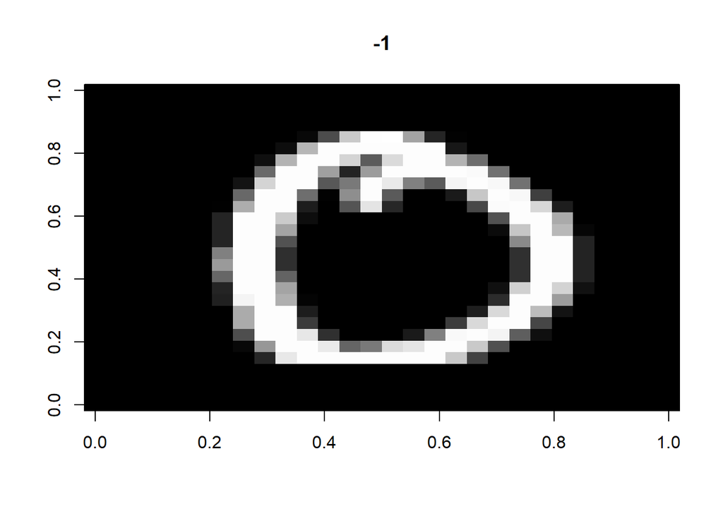

```r
rotate <- function(x) t(apply(x, 2, rev))

image_0 <- as.matrix(train_0_1[12,])
lable_0 <- train_labels_0_1[12]
image(rotate(matrix(image_0,28,28)), col=gray(0:255/255), main=lable_0)
```

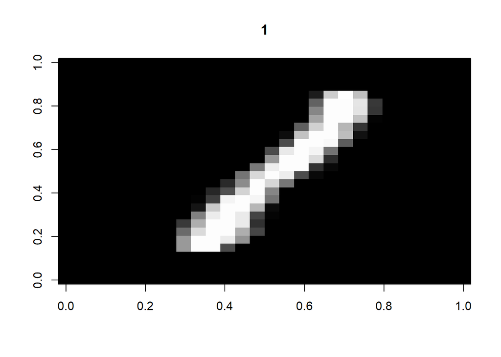

```r
image_1 = as.matrix(train_0_1[nrow(train_0_1)-12,])
lable_1 <- train_labels_0_1[nrow(train_0_1)-12]
image(rotate(matrix(image_1,28,28)), col=gray(0:255/255), main=lable_1)
```

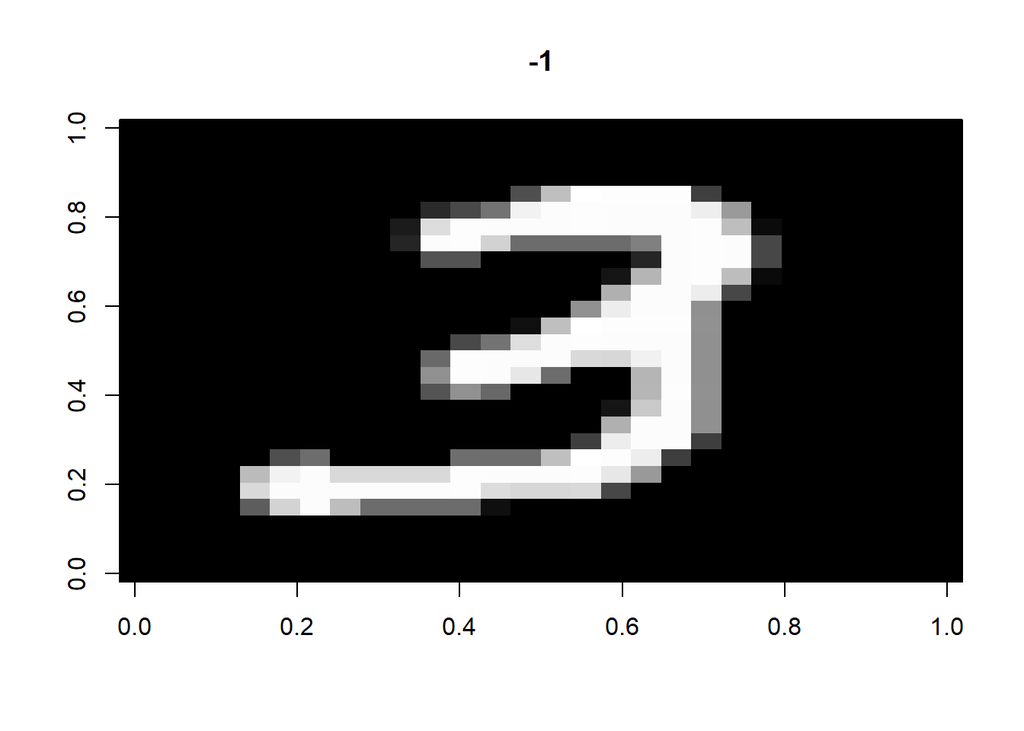

```r
image_3 = as.matrix(train_3_5[12,])
lable_3 <- train_labels_3_5[12]
image(rotate(matrix(image_3,28,28)), col=gray(0:255/255), main=lable_3)
```

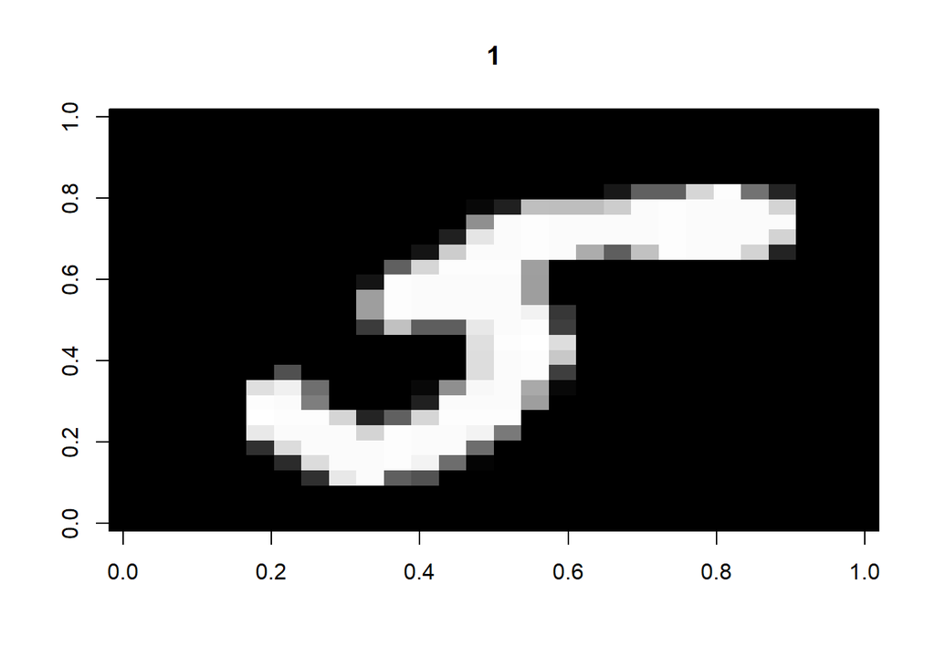

```r
image_5 = as.matrix(train_3_5[nrow(train_3_5)-12,])
lable_5 <- train_labels_3_5[nrow(train_3_5)-12]
image(rotate(matrix(image_5,28,28)), col=gray(0:255/255), main=lable_5)
```

## 2. Building Model

model() is a driver function which calls train(), predict() and accuracy functions on trasining and testing dataset. This functions accepts input of train_data, train_labels, test_data, test_labels, alpha. Aplha is a hyperparameter. Output of this function is a learned model parameters (theta) abd predicition accuraccy (train_acc and test_acc).

```r
model <- function(train_data, train_labels, test_data, test_labels, alpha) {
  theta <- train(train_data, train_labels, alpha)
  train_predicted_labels <- predict(theta, train_data)
  test_predicted_labels <- predict(theta, test_data)
  train_acc <- accuracy(train_labels, train_predicted_labels)
  test_acc <- accuracy(test_labels, test_predicted_labels)
  result_list<- list(theta, train_acc, test_acc)
  return(result_list)
}
```

train() function determines the optimal value of parameter vector theta. This accepts input as trainings data each with 785 features, corresponding label and learning rate alpha. Output of this fucntion is parameter vector “theta” which contains the optimal weights for each of the features and bias term.

train() implements following loss function to calculate loss occurs for a particular theta vector.
$$L(\theta) = log({1 + \exp(-y^{(i)} <\theta, x^{(i)}> )})$$
where $x^{(i)}$ is the data point represented in a vector of features, $y^{(i)}$ is the class label, and $\theta$ is the parameter vector.

Stochastic gradient descent algorithm is used to determine the minimum. When the loss function is at a minimum its derivative is zero. A random sample from training dataset with theta vector is used to calculate vector of partial dreviaties. These partial derivatives along with hyperparameters is used to update the vector theta.

The formula for the gradient descent:
$$\theta_j \leftarrow \theta_j - \alpha \sum_{i=1}^{n} \frac{1}{1 + \exp(-y^{(i)} <\theta, x^{(i)}> )}$$
where $x^{(i)}$ is the data point represented in a vector of features, $y^{(i)}$ is the class label, and $\theta$ is the parameter vector. The goal is to reach the $\theta$ that maximizes our likelihood function (given the data we use to train the model).

```r
train <- function(data, labels, alpha) {

  theta = runif(ncol(data))
  mean_epoch_loss_change = 0.0
  min_loss_change = 0.01
  max_num_epoch = 70

  for (epoch in seq(max_num_epoch)){

    index_values = sample(seq(nrow(data)))
    for (i in index_values) {
      x <- data[i,]
      y <- labels[i]
      part_derv = calc_part_derv(x,y, theta)
      theta = theta - (alpha * part_derv)
    }
    new_mean_epoch_loss <- calc_loss(data, labels, theta)

    if (abs(mean_epoch_loss_change - new_mean_epoch_loss) < min_loss_change) {
      break
    }
    mean_epoch_loss_change <- new_mean_epoch_loss
  }
  return(theta)

}

calc_part_derv <- function(x,y, theta){
  part_derv = (y%*%x ) / (exp(-y*(as.numeric(theta%*%x))) +1)
  return(part_derv)
}

calc_loss <- function(data, labels, theta) {
  batch_loss = 0
  losses <- log(1+exp(labels*(as.numeric(data%*%t(theta)))))
  batch_loss <- sum(losses)
  return(batch_loss/nrow(data))
}
```

## 3. Predicting Labels

Function predict() function is used to predict labels for train data as well as test dataset.  
This function accepts input as theta vector and dataset for prediction

A sigmoid function is used to predict the probability of a particular data row If a value in the resulting vector “predictions” is greater than 0.5 the label will be -1, otherwise it will 1. This function returns the vector of predicted labels

```r
predict <- function(theta, data) {
  predictions <- 1/(1+exp(-(data%*%t(theta))))
  predictions <-ifelse(predictions> 0.5, -1, 1)
  return(predictions)
}
```

## 4. Calculating Accuracy

This function compares two vectors, the true labels and the predicted labels and calculates prediction accurracy between 0 and 1.

```r
accuracy <- function(labels, labels_pred) {

  match <- labels == labels_pred
  acc <- (sum(match) / length(labels))
  return(acc)

}
```

## 5. Visualizing Results - Accuracy

Trainig and testing accuracy is calculated by training model with 10 various values of alpha with 10 iterations each. Selected values of alpha are 0.0001, 0.001, 0.005, 0.01, 0.05, 0.1, 0.2, 0.25, 0.3 and 0.35

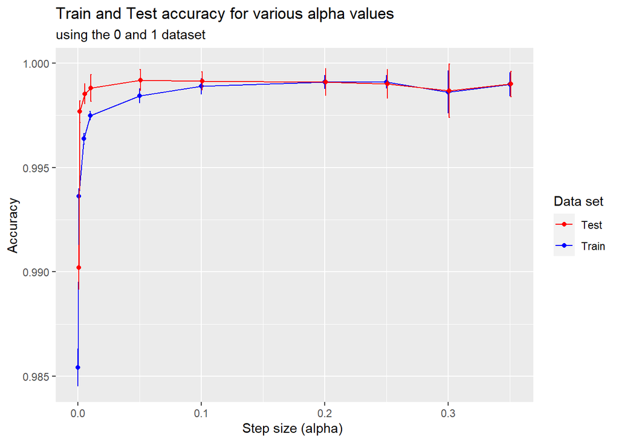

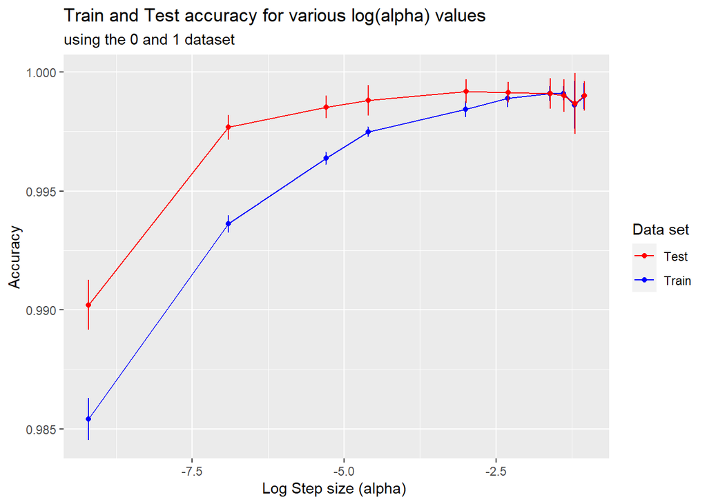

```r
alphas = c(0.0001, 0.001, 0.005, 0.01, 0.05, 0.1, 0.2, 0.25, 0.3, 0.35)
iterations <- 10


calc_alpha_values <- function(training_data, training_labels, testing_data, testing_labels, alphas) {

  result_matrix <- matrix(nrow=(length(alphas)*iterations), ncol=3, data = NA)
  for (a in seq(length(alphas))) {
    for (n in seq(iterations)) {
      result = model(training_data, training_labels, testing_data, testing_labels, alphas[a] )
      index = ((a-1)* iterations) + n
      result_matrix[index,] <- c(alphas[a], result[[2]],result[[3]])
    }
  }

  result_df <-as.data.frame(result_matrix)
  names(result_df) <- c("alpha", "train_acc", "test_acc")

  means <- aggregate(result_df[, 2:3], list(result_df$alpha), mean)
  sds <- aggregate(result_df[, 2:3], list(result_df$alpha), sd)

  stats <- as.data.frame(cbind(means[,1], means[,2], means[,3], sds[,2], sds[,3]))
  names(stats)  <- c("alpha", "mean_train_acc", "mean_test_acc", "sd_train_acc", "sd_test_acc")

  return(stats)

}


alpha_plots <- function(stats, dataset_name) {

  offset = .0007
  log_offset = 0.004

  plot_linear <- ggplot(stats) +
    geom_point(aes(x=alpha, y=mean_train_acc, col="Train")) +
    geom_line(aes(x=alpha, y=mean_train_acc, col="Train")) +
    geom_errorbar(aes(x=alpha, ymin=mean_train_acc - sd_train_acc, ymax=mean_train_acc + sd_train_acc, col = "Train"), width=.001) +
    geom_point(aes(x=alpha + offset, y=mean_test_acc, col="Test")) +
    geom_line(aes(x=alpha + offset, y=mean_test_acc, col="Test")) +
    geom_errorbar(aes(x=alpha + offset, ymin=mean_test_acc - sd_test_acc, ymax=mean_test_acc + sd_test_acc, col = "Test"), width=.001) +
    scale_color_manual(values= c("Train" ="blue", "Test"= "red" ), name="Data set") +
    xlab("Step size (alpha) ") +
    ylab("Accuracy") +
    ggtitle("Train and Test accuracy for various alpha values") +
    labs(subtitle =paste("using the", dataset_name))

  plot_log <- ggplot(stats) +
    geom_point(aes(x=log(alpha), y=mean_train_acc, col="Train")) +
    geom_line(aes(x=log(alpha), y=mean_train_acc, col="Train")) +
    geom_errorbar(aes(x= log(alpha), ymin=mean_train_acc - sd_train_acc, ymax=mean_train_acc + sd_train_acc, col = "Train"), width=.001) +
    geom_point(aes(x=log(alpha) + log_offset, y=mean_test_acc, col="Test")) +
    geom_line(aes(x=log(alpha) +log_offset, y=mean_test_acc, col="Test")) +
    geom_errorbar(aes(x= log(alpha)+log_offset, ymin=mean_test_acc - sd_test_acc, ymax=mean_test_acc + sd_test_acc, col = "Test"), width=.001) +
    scale_color_manual(values= c("Train" ="blue", "Test"= "red" ), name="Data set") +
    xlab("Log Step size (alpha) ") +
    ylab("Accuracy") +
    ggtitle("Train and Test accuracy for various log(alpha) values") +
    labs(subtitle =paste("using the", dataset_name))

  print(plot_linear)
  print(plot_log)

}

alpha_stats_0_1<- calc_alpha_values(train_0_1, train_labels_0_1, test_0_1, test_labels_0_1, alphas)
alpha_plots(alpha_stats_0_1, "0 and 1 dataset")
```

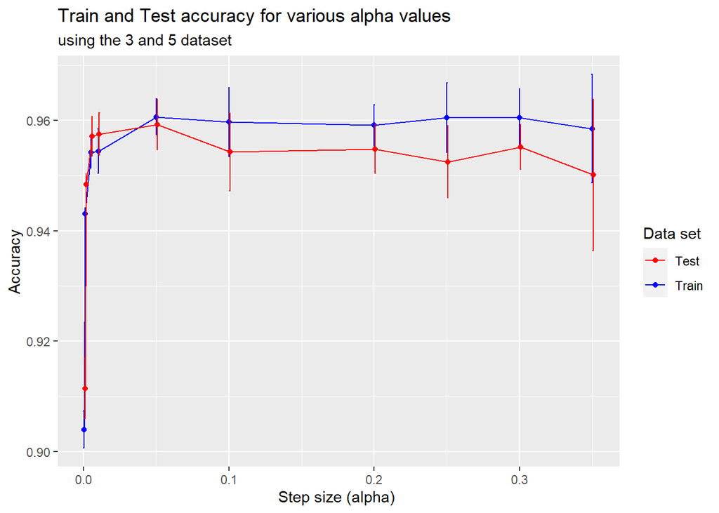

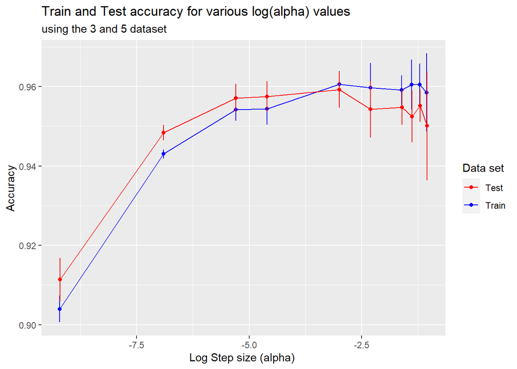

```r
alpha_stats_3_5<- calc_alpha_values(train_3_5, train_labels_3_5, test_3_5, test_labels_3_5, alphas)
alpha_plots(alpha_stats_3_5, "3 and 5 dataset")
```

## 5. Visualizing Results - Learning Curve

In this step model is trained using a fixed value of alpha (0.1) is used along with variying training sample size. The training accuracy was calculated using training data size of 5%, 10%, 20%, 30%, 40%, 50%, 60%, 70%, 70%, 80% 90% and 100%. Accuracy of testing dataset is calculated using the full size testing data set. Accuracy is calculated over 10 iterations.

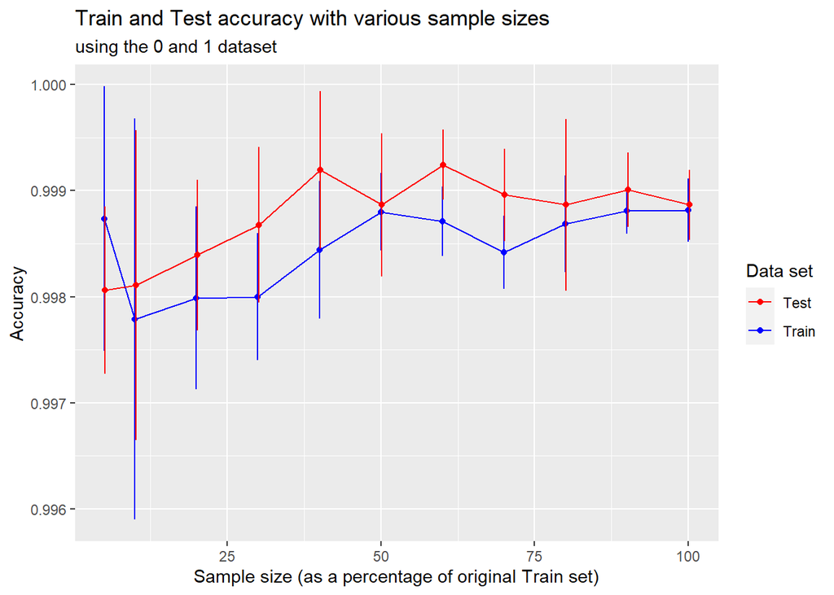

```r
alpha = 0.1
samples = c(0.05, 0.10, 0.2, 0.3, 0.4, 0.5, 0.6, 0.7, 0.8, 0.9, 1.0)
iterations = 10

calc_learning_curves <- function(samples, iterations, training_data, training_labels, testing_data, testing_labels, alpha) {

  result_matrix <- matrix(nrow=(length(samples)*iterations), ncol=3, data = NA)

  for (s in seq(length(samples))) {

    for (n in seq(iterations)){
      sample_indices <- sample(seq(nrow(training_data)), floor(nrow(training_data)*samples[s]))

      sample_training_data <- training_data[sample_indices,]
      sample_training_labels <- training_labels[sample_indices]

      result = model(sample_training_data, sample_training_labels, testing_data, testing_labels, alpha )

      index = ((s-1)* iterations) + n
      result_matrix[index,] <- c(samples[s], result[[2]],result[[3]])

    }
  }

  result_df <-as.data.frame(result_matrix)
  names(result_df)  <- c("sample_size", "train_acc", "test_acc")

  means <- aggregate(result_df[, 2:3], list(result_df$sample_size), mean)
  sds <- aggregate(result_df[, 2:3], list(result_df$sample_size), sd)

  stats <- as.data.frame(cbind(means[,1], means[,2], means[,3], sds[,2], sds[,3]))
  names(stats)  <- c("sample_size", "mean_train_acc", "mean_test_acc", "sd_train_acc", "sd_test_acc")

  return(stats)

}

learning_curve_plots <- function(stats, data_set_name) {

  offset = .15

  plot <- ggplot(stats) +
    geom_point(aes(x=sample_size*100, y=mean_train_acc, col="Train")) +
    geom_line(aes(x=sample_size*100, y=mean_train_acc, col="Train")) +
    geom_errorbar(aes(x= sample_size*100, ymin=mean_train_acc - sd_train_acc, ymax=mean_train_acc + sd_train_acc, col = "Train"), width=.001) +
    geom_point(aes(x=sample_size*100 + offset, y=mean_test_acc, col="Test")) +
    geom_line(aes(x=sample_size*100 + offset, y=mean_test_acc, col="Test")) +
    geom_errorbar(aes(x= sample_size*100 + offset, ymin=mean_test_acc - sd_test_acc, ymax=mean_test_acc + sd_test_acc, col = "Test"), width=.001) +
    scale_color_manual(values= c("Train" = "blue", "Test"= "red" ), name="Data set") +
    xlab("Sample size (as a percentage of original Train set)") +
    ylab("Accuracy") +
    ggtitle("Train and Test accuracy with various sample sizes") +
    labs(subtitle = paste("using the", data_set_name))

  print(plot)

}

lc_stats_0_1 <- calc_learning_curves(samples, iterations, train_0_1, train_labels_0_1, test_0_1, test_labels_0_1, alpha)
learning_curve_plots(lc_stats_0_1, "0 and 1 dataset")
```

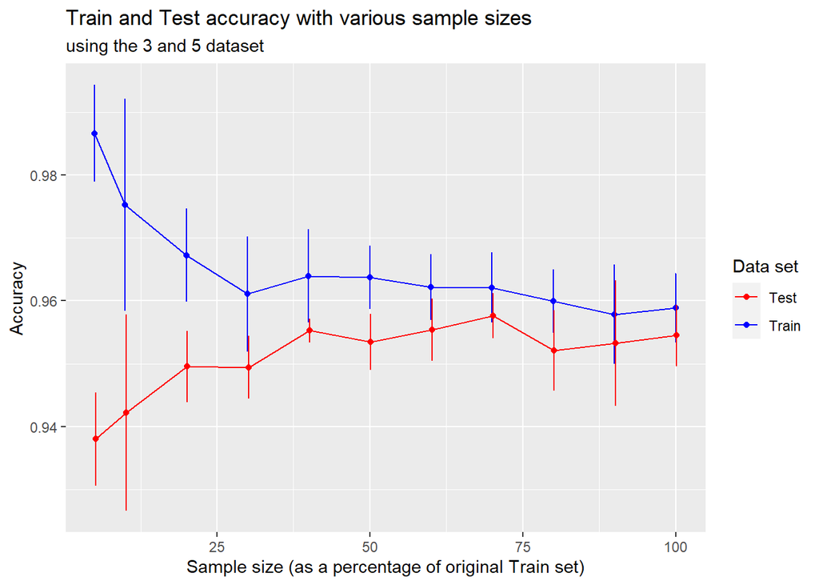

```r
lc_stats_3_5 <- calc_learning_curves(samples, iterations, train_3_5, train_labels_3_5, test_3_5, test_labels_3_5, alpha)
learning_curve_plots(lc_stats_3_5, "3 and 5 dataset")
```